# R1-Intro to R

Rob Wells

3/5/2020

# R1: Introduction to R and R Studio

### NICAR2020, New Orleans

[figure not shown]

# Orientation to R Studio

- **There are four main windows:**

  Script writing, R Markdown, Table Viewer: Upper Left  
  Environment - data loaded in R: Upper Right  
  Console - write commands in R: Lower Left  
  File Manager and Html table viewer: Bottom Right

# Part 1: Install software, Grab data

- **tidyverse** installs 8 separate software packages to perform data import, tidying, manipulation, visualisation, and programming install.packages(“tidyverse”)
- **Rio package**: easy importing features and janitor for data cleaning  
  install.packages(“rio”)  
  install.packages(“janitor”)

After you install a package on your hard drive, you can call it back up by summoning a library

Libraries are bits of software you will have to load each time into R to make things run.

```r
library(tidyverse)
library(rio)
library(janitor)
```

- **Tip**: Check to see what’s installed by clicking on “Packages” tab in File Manager, lower right pane

# Part 2: Examine Data

- **Open this file in Excel:**

https://github.com/profrobwells/Guest_Lectures/blob/master/Intro_To_R/RealMediaSalariesCleaned.xlsx

- **Select RealMediaSalaries2 tab**

IRE Old School: Four Corners Test!

```
13 Columns
1658 Rows
Numberic data in Salary, Years Experience
Mixed string data in Gender Identity / Ethnicity, Job duties
```

– **Import Data**

```r
MediaBucks <- rio::import("https://github.com/profrobwells/Guest_Lectures/blob/master/Intro_To_R/RealMediaSalariesCleaned.xlsx?raw=true", which = "RealMediaSalaries2")
```

What happened? Look at the table

```r
View(MediaBucks)
```

What happened?

```
R grabbed the spreadsheet from the folder
We told R to grab the first sheet, RealMediaSalaries2
R created a dataframe called MediaBucks
```

Basics of R: <- is known as an “assignment operator.”

```
It means: “Make the object named to the left equal to the output of the code to the right.”
```

# Part 3: Explore Data

– **How many rows?**

```r
nrow(MediaBucks)
```

```
## [1] 1658
```

– **How many columns?**

```r
ncol(MediaBucks)
```

```
## [1] 13
```

– **Names of your columns**

```r
colnames(MediaBucks)
```

```
##  [1] "TITLE"                     "COMPANY"
##  [3] "Salary"                    "Salary_Details"
##  [5] "Salary_Details2"           "Race"
##  [7] "Gender"                    "YEARS_EXPERIENCE"
##  [9] "LOCATION"                  "JOB_DUTIES"
## [11] "PREV_SALARIES_TITLES"      "SALARY_original"
## [13] "Gender_Ethnicity_Original"
```

OR: names(MediaBucks)

– **Check data types**

```r
str(MediaBucks)
```

```
## 'data.frame':    1658 obs. of  13 variables:
##  $ TITLE                    : chr  "Photojournalist" "Staff Writer" "Staff reporter" "Reporter" ...
##  $ COMPANY                  : chr  "College Student Newspaper" "Paxton Media" "Schurz Communications Inc." "Hearst Newspapers" ...
##  $ Salary                   : num  0 12 12 13.2 14.9 ...
##  $ Salary_Details           : chr  NA "hour" "hour" "hour" ...
##  $ Salary_Details2          : chr  NA "anhour" "-2012.0" "~32,000/year" ...
##  $ Race                     : chr  "asian" "white" "white" "white" ...
##  $ Gender                   : chr  "male" "female" "female" "female" ...
##  $ YEARS_EXPERIENCE         : chr  "3.0" "8.0" "2.0" "3.0" ...
##  $ LOCATION                 : chr  NA "Georgia" "Central Kentucky" "Houston" ...
##  $ JOB_DUTIES               : chr  "Photo" "Write and cover news stories, photograph news, write monthly health magazine, social media director" "Reported on anything and everything: local government, breaking news, features, op/eds, columns. Took pictures,"| __truncated__ "Report on communities …
##  $ PREV_SALARIES_TITLES     : chr  NA NA NA NA ...
##  $ SALARY_original          : chr  "0.0" "$12 an hour" "$12/hour (2012)" "13.25/hour ~ 32,000/year" ...
##  $ Gender_Ethnicity_Original: chr  "Cis male asian" "White female" "cis white female" "Cis white female" ...
```

- **Let’s look at the first six rows**

```r
head(MediaBucks)
```

```
##             TITLE                    COMPANY Salary Salary_Details
## 1 Photojournalist  College Student Newspaper   0.00           <NA>
## 2    Staff Writer               Paxton Media  12.00           hour
## 3  Staff reporter Schurz Communications Inc.  12.00           hour
## 4        Reporter          Hearst Newspapers  13.25           hour
## 5  Staff Reporter           Ogden Newspapers  14.91           hour
## 6   Desk Assitant                       KTLA  15.00           hour
##   Salary_Details2     Race Gender    YEARS_EXPERIENCE         LOCATION
## 1            <NA>    asian   male                 3.0             <NA>
## 2          anhour    white female                 8.0          Georgia
## 3         -2012.0    white female                 2.0 Central Kentucky
## 4    ~32,000/year    white female                 3.0          Houston
## 5         perhour    white   male 3+ years experience             Utah
## 6            <NA> noanswer female                 2.0      Los Angeles
##                                                                                                                                                                                                                                                                                                          …
## 1                                                                                                                                                                                                                                                                                                        …
## 2                                                                                                                                                                                                                                                                                                        …
## 3                                                                                                                                                                                                                                                                                                        …
## 4                                                                                                                                                                                                                                                                                                        …
## 5                                                                                                                                                                                                                                                                                                        …
## 6 Organize daily field drives and retrieves file videos\nUse FTP system to send/receive video files from the field\nMakes beat checks of police and fire departments\nLog/transcribe daily video feeds\nAnswers viewer phone calls, taking stories from viewers\nChecks for possible stories via all soci…
##   PREV_SALARIES_TITLES          SALARY_original Gender_Ethnicity_Original
## 1                 <NA>                      0.0            Cis male asian
## 2                 <NA>              $12 an hour              White female
## 3                 <NA>          $12/hour (2012)          cis white female
## 4                 <NA> 13.25/hour ~ 32,000/year          Cis white female
## 5                 <NA>          $14.91 per hour            cis white male
## 6                 <NA>                 $15/hour                cis female
```

- **Here is a quick way to view the range of your data on just salary column**

```r
summary(MediaBucks$Salary)
```

```
##    Min. 1st Qu.  Median    Mean 3rd Qu.    Max.    NA's
##       0   42000   60000   64194   78000  770000       4
```

- **Size and scope**

```r
sum(MediaBucks$Salary, na.rm=TRUE)
```

```
## [1] 106177432
```

$106 million! for 1,658 journalists

Context: NYT earnings in 2018 = $126m in 2018 Facebook earnings for two days: $135 million (Q32019=$6.1B)

- **average**

```r
mean(MediaBucks$Salary, na.rm=TRUE)
```

```
## [1] 64194.34
```

- **Distribution by Quantile**

```r
quantile(MediaBucks$Salary, c(0.1, 0.2, 0.3, 0.4,0.5, 0.6, 0.7, 0.8, 0.9), na.rm=TRUE)
```

```
##    10%    20%    30%    40%    50%    60%    70%    80%    90%
##  28720  39000  45000  52000  60000  65000  75000  84000 101700
```

– **Navigation Tips**

```
Shortcut Commands
Tab - Autocomplete
In Console Window (lower left)
Control (or Command) + UP arrow - last lines run
Control (or Command) + Enter - Runs current or selected lines of code in the top left box of RStudio
Shift + Control (or Command) +P - Reruns previous region code
```

# Part 4: dplyr

- **dplyr has many tools for data analysis**

  select Choose which columns to include. filter Filter the data. arrange Sort the data, by size for continuous variables, by date, or alphabetically. group_by Group the data by a categorical variable.
- **Build a simple summary table by Gender**

```r
Summary <- MediaBucks %>%
  select(Gender, Salary) %>%
  group_by(Gender) %>%
  summarize(Total = sum(Salary, na.rm=TRUE))
```

- **What is the sample size?**

```r
Gender <- MediaBucks %>%
  count(Gender) %>%
  arrange(desc(n))
```

- **Better idea: Check Averages!**

  Build a simple summary table by Gender

```r
Summary <- MediaBucks %>%
  select(Gender, Salary) %>%
  group_by(Gender) %>%
  summarize(Avg_Salary = mean(Salary, na.rm=TRUE))
```

- **Quick filter out hourly workers**

```r
MediaSalary <- MediaBucks %>%
  filter(Salary >= 1000)
```

- **Questions**

  1: View the range of your data  
  2: Number of rows 3: Number of rows cut with hourly filter
- **Answer: #1**

```r
summary(MediaSalary$Salary)
```

```
##    Min. 1st Qu.  Median    Mean 3rd Qu.    Max.
##    1000   45000   61000   68364   80000  770000
```

- **Answer: #2**

```r
nrow(MediaSalary)
```

```
## [1] 1553
```

- **Answer: #3**

```r
nrow(MediaBucks)-nrow(MediaSalary)
```

```
## [1] 105
```

- **Find Your News Organization**

Use a Filter

```r
WSJ <- subset(MediaBucks, COMPANY=="WallStreetJournal")
summary(WSJ$Salary)
```

```
##    Min. 1st Qu.  Median    Mean 3rd Qu.    Max.
##      38   41000   51100   64275   75750  236000
```

- **Search Using Wildcards**

```r
Journal <- subset(MediaBucks, grepl("?Journal", COMPANY))
Bloom <- subset(MediaBucks, grepl("?Bloomberg", COMPANY))
```

- **Questions**

  1: Build a table for NewYorkTimes employees 2: Determine median salary of NewYorkTimes employees 3: Identify title, gender and race of the highest paid position at NYT’ 4: Search for “Business” in Company, check salaries, compare to “Bloomberg”
- **Answers:**
- **1: Build a table for NewYorkTimes employees**

```r
NYT <- subset(MediaBucks, COMPANY=="NewYorkTimes")
```

- **2: Determine median salary of NewYorkTimes employees**

```r
summary(NYT$Salary)
```

```
##    Min. 1st Qu.  Median    Mean 3rd Qu.    Max.
##     800   50000   52000   69692   55000  350000
```

- **#3: Identify title, gender and race of the highest paid position at NYT**

```r
NYT %>%
  filter(Salary == 350000)
```

```
##                    TITLE      COMPANY Salary Salary_Details
## 1 Executive Editor, News NewYorkTimes 350000           <NA>
##   Salary_Details2  Race   Gender YEARS_EXPERIENCE LOCATION JOB_DUTIES
## 1            <NA> black noanswer             30.0 New York       <NA>
##   PREV_SALARIES_TITLES SALARY_original Gender_Ethnicity_Original
## 1                 <NA>        350000.0                     Black
```

- **4: Search for “Business” in Company, check median salaries, compare to “Bloomberg”**

```r
Biz <- subset(MediaBucks, grepl("?Business", COMPANY))
summary(Biz$Salary)
```

```
##    Min. 1st Qu.  Median    Mean 3rd Qu.    Max.
##      18   37000   46000   45048   58000   65000
```

$46,000

```r
Bloom <- subset(MediaBucks, grepl("?Bloomberg", COMPANY))
summary(Bloom$Salary)
```

```
##    Min. 1st Qu.  Median    Mean 3rd Qu.    Max.
##   21840   45000   50000   55026   55000  210000
```

# Part 5: More Tables

- **Build a table with several companies of your choice**

```r
BigBoys <- filter(MediaSalary, COMPANY %in% c("NewYorkTimes", "WallStreetJournal", "Bloomberg"))
```

- **Table with just reporter salaries**

```r
Reporters <- subset(MediaBucks, grepl("?reporter", TITLE))
summary(Reporters$Salary)
```

```
##    Min. 1st Qu.  Median    Mean 3rd Qu.    Max.
##      12   35000   50625   57077   67250  230504
```

- **Questions:**

  1: Who is making $230,504 as a reporter??? 2: Make a table for editors, figure out medians. 3: Find highest paid editor. Resent them. 4: Make a table for any position involving data
- **Answers:**
- **1: Who is making $230,504 as a reporter???**

```r
Reporters %>%
  filter(Salary == 230504)
```

```
##             TITLE    COMPANY Salary Salary_Details
## 1 senior reporter ProPublica 230504          bonus
##                         Salary_Details2  Race Gender YEARS_EXPERIENCE
## 1 (plus$52,000inadditionalcompensation) white   male             <NA>
##   LOCATION JOB_DUTIES PREV_SALARIES_TITLES
## 1      NYC    writing                 <NA>
##                                      SALARY_original
## 1 $230,504 (plus $52,000 in additional compensation)
##   Gender_Ethnicity_Original
## 1                       M/W
```

- **#2: Make a table for editors, figure out medians.**

```r
Editors <- subset(MediaBucks, grepl("?editor", TITLE))
summary(Editors$Salary)
```

```
##     Min.  1st Qu.   Median     Mean  3rd Qu.     Max.
##     11.5  45000.0  60240.0  64378.6  75000.0 245000.0
```

-**#3: Find highest paid editor. Resent them.**

```r
Editors %>%
  filter(Salary == 245000)
```

```
##                TITLE   COMPANY Salary Salary_Details Salary_Details2
## 1 editorial director CondeNast 245000           <NA>            <NA>
##       Race Gender YEARS_EXPERIENCE LOCATION
## 1 noanswer female             18.0 new york
##                                                                                                                                JOB_DUTIES
## 1 directing editorial team of 4+ people to produce print and integrated products on behalf of in-house brands, as well as branded content
##                                    PREV_SALARIES_TITLES SALARY_original
## 1 175k + guaranteed bonus for similar role at Time Inc.            245k
##   Gender_Ethnicity_Original
## 1                    female
```

-**#4: Make a table for any position involving data**

```r
Data <- subset(MediaBucks, grepl(("?Data"), TITLE))
summary(Data$Salary)
```

```
##    Min. 1st Qu.  Median    Mean 3rd Qu.    Max.
##   17000   43000   60000   68062   90000  125000
```

# Part 6: Chart By Gender

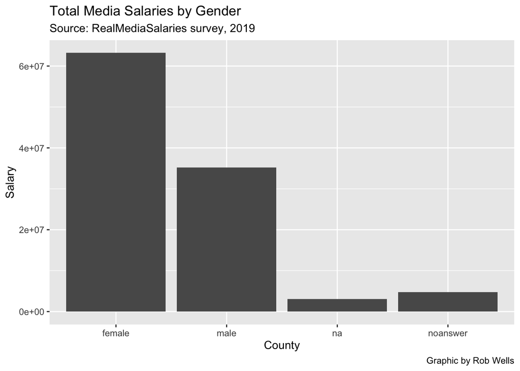

```r
MediaBucks %>% ggplot(aes(y = Salary, x=Gender)) +
  geom_bar(stat = "identity") +
  labs(title = "Total Media Salaries by Gender",
       subtitle = "Source: RealMediaSalaries survey, 2019 ",
       caption = "Graphic by Rob Wells",
       x="County",
       y="Salary")
```

This needs some work

- **Get rid of scientific notation**

```r
options("scipen"=100, "digits"=4)
```

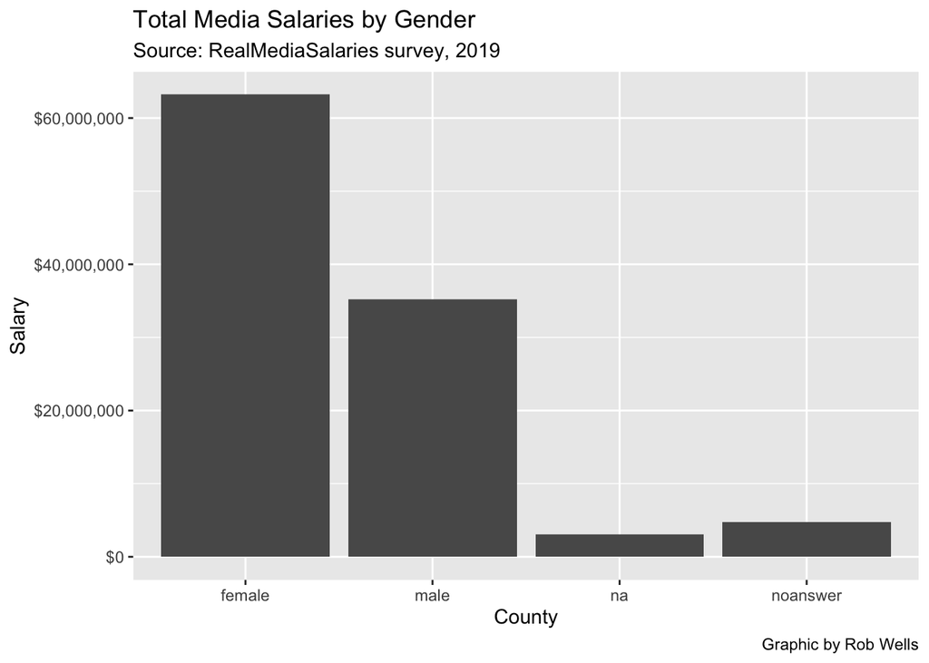

```r
MediaBucks %>% ggplot(aes(y = Salary, x=Gender)) +
  geom_bar(stat = "identity") +
   scale_y_continuous(labels = scales::dollar) +
  labs(title = "Total Media Salaries by Gender",
       subtitle = "Source: RealMediaSalaries survey, 2019 ",
       caption = "Graphic by Rob Wells",
       x="County",
       y="Salary")
```

- **Add Color**

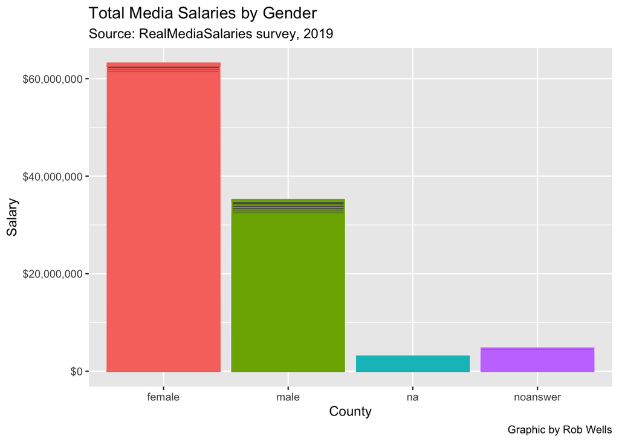

```r
MediaBucks %>% ggplot(aes(y = Salary, x=Gender, color = Gender)) +
  geom_bar(stat = "identity") +
  theme(legend.position = "none") +
  #coord_flip() +     #this makes it a horizontal bar chart instead of vertical
  scale_y_continuous(labels = scales::dollar) +
  labs(title = "Total Media Salaries by Gender",
       subtitle = "Source: RealMediaSalaries survey, 2019 ",
       caption = "Graphic by Rob Wells",
       x="County",
       y="Salary")
```

- **Average salaries is the story!**

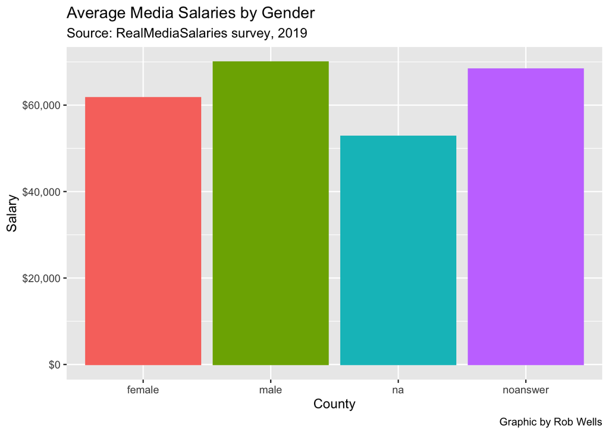

```r
MediaBucks %>%
  select(Gender, Salary) %>%
  group_by(Gender) %>%
  summarize(mean = mean(Salary, na.rm=TRUE))  %>%
  ggplot(aes(y = mean, x=Gender, color = Gender, fill=Gender)) +
  geom_bar(stat = "identity") +
  theme(legend.position = "none") +
  scale_y_continuous(labels = scales::dollar) +
  labs(title = "Average Media Salaries by Gender",
       subtitle = "Source: RealMediaSalaries survey, 2019 ",
       caption = "Graphic by Rob Wells",
       x="County",
       y="Salary")
```

- **Export: Lower right, Export as .png file**

# Wrap Up: What You Have Learned So Far

```
How to navigate in R studio
How to install libraries and packages
How to import a .xlsx file into R
How to obtain summary statistics (summary)
How to build basic tables from a dataset
How to conduct filter queries from a dataset
How to build basic charts
```

# Tutorials

–**All Cheat Sheets** https://www.rstudio.com/resources/cheatsheets/

–**MaryJo Webster tutorials** http://mjwebster.github.io/DataJ/R_tutorials/opiate_deaths.nb.html https://github.com/mjwebster/R_tutorials/blob/master/Using_R.Rmd

–**Aldhous’ R tutorial** http://paldhous.github.io/NICAR/2018/r-analysis.html

–**Ron Campbell Lecture** https://github.com/roncampbell/NICAR2018/blob/master/Intro%20to%20R.md

–**Excellent Tutorial Spelling out Excel and Comparable Commands in R** https://trendct.org/2015/06/12/r-for-beginners-how-to-transition-from-excel-to-r/ https://docs.google.com/presentation/d/1O0eFLypJLP-PAC63Ghq2QURAnhFo6Dxc7nGt4y_l90s/edit#slide=id.g1bc441664e_0_59

–**Andrew Ba Tran first Data Analysis Steps Using R** https://docs.google.com/presentation/d/1O0eFLypJLP-PAC63Ghq2QURAnhFo6Dxc7nGt4y_l90s/edit#slide=id.p

–**Charts** https://www.rdocumentation.org/packages/ggplot2/versions/1.0.1/topics/geom_bar http://www.cookbook-r.com/Graphs/Bar_and_line_graphs_(ggplot2)/

–**Base R Cheat Sheet** https://www.povertyactionlab.org/sites/default/files/r-cheat-sheet.pdf

## Contact for questions

```
Rob Wells, PhD
University of Arkansas
LinkedIn: https://www.linkedin.com/in/rob-wells-7929329/
@rwells1961
rswells@uark.edu
```

**–30–**